# **Stat 112 - Recitation 7**

> Ozancan Ozdemir - ozancan@metu.edu.tr

This document is created using the following sources.

[CS231-Stanford University](https://cs231n.github.io/python-numpy-tutorial/#numpy)

[NumPy](https://numpy.org/)

[Jay Alamar's Blog](http://jalammar.github.io/visual-numpy/)

"

## Introduction to Numpy

**Reminder**

```python
import numpy as np # import the numpy package
```

```python
a = np.array([1, 2, 3])  # Create a rank 1 array (1D array)
a
```

```
array([1, 2, 3])
```

```python
type(a)
```

```
numpy.ndarray
```

```python
b = np.array([[1,2,3],[4,5,6]]) #Create 2D array
b
```

```
array([[1, 2, 3],
       [4, 5, 6]])
```

```python
np.mean(b)
```

```
3.5
```

### Basic Operators

What makes working with `numpy` so powerful and convenient is that it comes with many *vectorized* math functions for computation over elements of an array. These functions are highly optimized and are *very* fast - much, much faster than using an explicit `for` loop.

For example, let’s create a large array of random values and then sum it both ways. We’ll use a `%%time` *cell magic* to time them.

```python
a = np.random.random(100000000)
```

```python
%%time
x = np.sum(a)
```

```
CPU times: user 72.4 ms, sys: 0 ns, total: 72.4 ms
Wall time: 73.8 ms
```

```python
%%time
x = 0
for element in a:
  x = x + element
```

```
CPU times: user 15.9 s, sys: 36.2 ms, total: 15.9 s
Wall time: 16 s
```

Look at the “Wall Time” in the output - note how much faster the vectorized version of the operation is! This type of fast computation is a major enabler of machine learning, which requires a lot of computation.

Whenever possible, we will try to use these vectorized operations.

Some mathematic functions are available both as operator overloads and as functions in the numpy module.

For example, you can perform an elementwise sum on two arrays using either the + operator or the `add()` function.

[figure not shown]

```python
x = np.array([[1,2],[3,4]], dtype=np.float64)
y = np.array([[5,6],[7,8]], dtype=np.float64)

# Elementwise sum; both produce the array
print(x + y)
print(np.add(x, y))
```

```
[[ 6.  8.]
 [10. 12.]]
[[ 6.  8.]
 [10. 12.]]
```

And this works for other operations as well, not only addition:

[figure not shown]

```python
# Elementwise difference; both produce the array
print(x - y)
print(np.subtract(x, y))
```

```
[[-4. -4.]
 [-4. -4.]]
[[-4. -4.]
 [-4. -4.]]
```

```python
# Elementwise product; both produce the array
print(x * y)
print(np.multiply(x, y))
```

```
[[ 5. 12.]
 [21. 32.]]
[[ 5. 12.]
 [21. 32.]]
```

```python
# Elementwise division; both produce the array
# [[ 0.2         0.33333333]
#  [ 0.42857143  0.5       ]]
print(x / y)
print(np.divide(x, y))
```

```
[[0.2        0.33333333]
 [0.42857143 0.5       ]]
[[0.2        0.33333333]
 [0.42857143 0.5       ]]
```

```python
# Elementwise square root; produces the array
# [[ 1.          1.41421356]
#  [ 1.73205081  2.        ]]
print(np.sqrt(x))
```

```
[[1.         1.41421356]
 [1.73205081 2.        ]]
```

```python
# Elementwise exponential power; produces array
#[[ 2.71828183  7.3890561 ]
#[20.08553692 54.59815003]]
print(np.exp(x))
```

```
[[ 2.71828183  7.3890561 ]
 [20.08553692 54.59815003]]
```

```python
np.round(np.exp(x)) #Round an array to the given number of decimals.;elementwise
```

```
array([[ 3.,  7.],
       [20., 55.]])
```

```python
np.ceil(np.exp(x)) #Return the ceiling of the input, element-wise.
```

```
array([[ 3.,  8.],
       [21., 55.]])
```

```python
np.floor(np.exp(x)) #Return the floor of the input, element-wise.
```

```
array([[ 2.,  7.],
       [20., 54.]])
```

You can find out more functions from [here](https://numpy.org/doc/stable/user/quickstart.html#basic-operations).

Note that `*` operator is not a matrix multipication operator in contrast to other programming languages like MATLAB. `dot()` function instead is used to compute inner products of vectors, to multiply a vector by a matrix, and to multiply matrices. `dot()` is available both as a function in the numpy module and as an instance method of array objects:

[figure not shown]

```python
import numpy as np
x = np.array([[1,2],[3,4]])
y = np.array([[5,6],[7,8]])

v = np.array([9,10])
w = np.array([11, 12])

print(x)

print(y)

print(v)

print(w)
```

```
[[1 2]
 [3 4]]
[[5 6]
 [7 8]]
[ 9 10]
[11 12]
```

```python
# Inner product of vectors; both produce 219
print(v.dot(w))
print(np.dot(v, w))
```

```
219
219
```

You can also use the `@` operator which is equivalent to numpy's `dot` operator.

```python
print(v @ w)
```

```
219
```

#### **Exercise 1**

Multiply a 5x3 matrix by a 3x2 matrix (real matrix product) where the all elements in both matrices are 1.

**Hint:** Use `np.ones()`

**The Expected Output:**

```python
m1 = np.ones((5,3))
m1
```

```
array([[1., 1., 1.],
       [1., 1., 1.],
       [1., 1., 1.],
       [1., 1., 1.],
       [1., 1., 1.]])
```

```python
m2 = np.ones((3,2))
m2
```

```
array([[1., 1.],
       [1., 1.],
       [1., 1.]])
```

```python
m1@m2
```

```
array([[3., 3.],
       [3., 3.],
       [3., 3.],
       [3., 3.],
       [3., 3.]])
```

#### **Mathematical and Statistical Functions**

Numpy also provides many useful functions for performing computations on arrays, such as `min()`, `max()`, `sum()`,`mean()`,`median()`, `quantile()`, `cov()`, `corrcoef()`,and others:

You can see the full list for the **mathematical functions** from [here](https://numpy.org/doc/stable/reference/routines.math.html) and **statistical functions** from [here](https://numpy.org/doc/stable/reference/routines.statistics.html)

[figure not shown]

```python
x = np.array([[1, 2], [3, 4], [5, 6]])

print(x)
```

```
[[1 2]
 [3 4]
 [5 6]]
```

```python
print(np.min(x))  # Show min of all elements; prints "1"
```

```
1
```

```python
print(np.max(x))  # Show max of all elements; prints "6"
```

```
6
```

```python
print(np.mean(x))  # Compute the mean of the all elements; prints "3.5"
```

```
3.5
```

$\frac{\sum_{i=1}^{n=6} i}{6} = 3.5$

```python
print(np.median(x))  # Compute the median of the all elements; prints "3.5"
```

```
3.5
```

```python
print(np.quantile(x, 0.75))  # Compute the 3rd quartile of the all elements; prints "4.75"
```

```
4.75
```

```python
print(np.std(x))  # Compute the standard deviation of the all elements; prints "1.708"
```

```
1.707825127659933
```

```python
print(np.sum(x))  # Compute sum of all elements; prints "21"
```

```
21
```

```python
print(np.cumsum(x))  # Compute cumulative sum of all elements; prints "21"
```

```
[ 1  3  6 10 15 21]
```

Now, let's see how the correlating function works.

```python
a = np.array([0.45959958, 0.1613048 , 0.76000473, 0.07536241, 0.60232491,
       0.00167602, 0.71653501, 0.40927931, 0.78030462, 0.15509362])
b = np.array([7.17485455, 5.50089164, 7.35266241, 5.64972889, 7.62871573,
       5.01298309, 7.57177999, 6.81378627, 7.3785654 , 5.79279215])
```

```python
np.cov(a,b)
```

```
array([[0.08872592, 0.28013513],
       [0.28013513, 0.98124247]])
```

```python
np.corrcoef(a,b)
```

```
array([[1.        , 0.94941078],
       [0.94941078, 1.        ]])
```

Not only can we aggregate all the values in a matrix using these functions, but we can also aggregate across the rows or columns by using the `axis` parameter:

[figure not shown]

```python
x = np.array([[1, 2], [5, 3], [4, 6]])

print(np.max(x, axis=0))  # Compute max of each column; prints "[5 6]"
```

```
[5 6]
```

```python
print(np.max(x, axis=1))  # Compute max of each row; prints "[2 5 6]"
```

```
[2 5 6]
```

```python
print(np.mean(x, axis=1))  # Compute mean of each row; prints "[1.5 4  5]"
```

```
[1.5 4.  5. ]
```

`np.sort` returns the sorted copy of the array.

```python
a
```

```
array([0.45959958, 0.1613048 , 0.76000473, 0.07536241, 0.60232491,
       0.00167602, 0.71653501, 0.40927931, 0.78030462, 0.15509362])
```

```python
np.sort(a) #from smallest to largest
```

```
array([0.00167602, 0.07536241, 0.15509362, 0.1613048 , 0.40927931,
       0.45959958, 0.60232491, 0.71653501, 0.76000473, 0.78030462])
```

```python
np.sort(a)[::-1] #from largest to smallest
```

```
array([0.78030462, 0.76000473, 0.71653501, 0.60232491, 0.45959958,
       0.40927931, 0.1613048 , 0.15509362, 0.07536241, 0.00167602])
```

**Extra**

You can generate order your data in a random order.

```python
np.random.shuffle(a)
a
```

```
array([0.00167602, 0.60232491, 0.45959958, 0.71653501, 0.15509362,
       0.40927931, 0.78030462, 0.07536241, 0.1613048 , 0.76000473])
```

#### **Exercise 2**

Create a 1D array having 10 elements. You can use .random function.

Calculate the five number summaries of the array.

**Answer:**

```python
ex2 = np.random.random(10)
ex2
```

```
array([0.06354225, 0.25978659, 0.71671978, 0.00627995, 0.30814461,
       0.72897845, 0.51545988, 0.57818907, 0.69467508, 0.42554708])
```

```python
print(ex2.min())
print(np.quantile(ex2,0.25))
print(np.median(ex2))
print(np.quantile(ex2,0.75))
print(np.max(ex2))
```

```
0.006279953666841864
0.27187609181029326
0.47050348192359215
0.6655535802201438
0.7289784495557392
```

#### **Array Indexing and Slicing**

If you are familiar with Python's standard list indexing, indexing in NumPy will feel quite familiar. It offers several ways to index into arrays.

In a one-dimensional array, the value (counting from zero) can be accessed by specifying the desired index in square brackets, just as with Python lists:

[figure not shown]

And you can index and slice numpy arrays in multiple dimensions. If slicing an array with more than one dimension, you should specify a slice for each dimension using a comma-separated tuple of indices:

[figure not shown]

```python
x1 = np.random.random(10) #create one dimensional array
x1
```

```
array([0.84473521, 0.25480532, 0.04202275, 0.97207065, 0.17375351,
       0.76710637, 0.48383864, 0.51858609, 0.64259706, 0.54944136])
```

```python
x1[0]
```

```
0.8447352143549912
```

```python
x1[4]
```

```
0.17375350556132374
```

```python
x1[0:2]
```

```
array([0.84473521, 0.25480532])
```

```python
x1[len(x1)-1] #the accessing the last entry
```

```
0.5494413589911319
```

Alternatively, you can use negative indices to index from the end of the array.

```python
x1[-1]
```

```
0.5494413589911319
```

```python
x1[-2]
```

```
0.6425970578161072
```

As stated above, you can use comma seperated tupples for multidimensional array.

```python
# Create the following rank 2 array with shape (3, 4)
a = np.array([[1,2,3,4], [5,6,7,8], [9,10,11,12]])
a
```

```
array([[ 1,  2,  3,  4],
       [ 5,  6,  7,  8],
       [ 9, 10, 11, 12]])
```

```python
# Use slicing to pull out the subarray showing the first entry
a[0,0]
```

```
1
```

```python
# Use slicing to pull out the subarray showng the (2,3)^th element of the array
a[1,2]
```

```
7
```

Two ways of accessing the data in the middle row of the array. Mixing integer indexing with slices yields an array of lower rank, while using only slices yields an array of the same rank as the original array:

```python
row_r1 = a[1, :]    # Rank 1 view of the second row of a
row_r2 = a[1:2, :]  # Rank 2 view of the second row of a
row_r3 = a[[1], :]  # Rank 2 view of the second row of a
print(row_r1, row_r1.shape)
print(row_r2, row_r2.shape)
print(row_r3, row_r3.shape)
```

```
[5 6 7 8] (4,)
[[5 6 7 8]] (1, 4)
[[5 6 7 8]] (1, 4)
```

```python
# We can make the same distinction when accessing columns of an array:
col_r1 = a[:, 1]
col_r2 = a[:, 1:2]
print(col_r1, col_r1.shape)
print()
print(col_r2, col_r2.shape)
```

```
[ 2  6 10] (3,)

[[ 2]
 [ 6]
 [10]] (3, 1)
```

```python
# Use slicing to pull out the subarray consisting of the first 2 rows
# and columns 1 and 2; b is the following array of shape (2, 2):
# [[2 3]
#  [6 7]]
b = a[:2, 1:3]
print(b)
```

```
[[2 3]
 [6 7]]
```

**Integer array indexing**: When you index into numpy arrays using slicing, the resulting array view will always be a subarray of the original array. In contrast, integer array indexing allows you to construct arbitrary arrays using the data from another array. Here is an example:

```python
a = np.array([[1,2], [3, 4], [5, 6]])

a
```

```
array([[1, 2],
       [3, 4],
       [5, 6]])
```

```python
# An example of integer array indexing.
# The returned array will have shape (3,) and
print(a[[0, 1, 2], [0, 1, 0]])

# The above example of integer array indexing is equivalent to this:
print(np.array([a[0, 0], a[1, 1], a[2, 0]]))
```

```
[1 4 5]
[1 4 5]
```

#### **Exercise 3.1**

Create a sequence consisting of numbers between 0 and 9.

**Hint:** Use `np.arange()`

```python
a = np.arange(0,10,1)
a
```

```
array([0, 1, 2, 3, 4, 5, 6, 7, 8, 9])
```

**a) Pull out the second element.**

```python
a[1]
```

```
1
```

**b) Pull out the first 5 elements**

```python
a[0:5]
```

```
array([0, 1, 2, 3, 4])
```

#### **Exercise 3.2**

Create the following 2D Array.

```
array([[12,  5,  2],
       [ 7,  6,  8]])
```

```python
ex_32 = np.array([[12,  5,  2],
       [ 7,  6,  8]])
ex_32
```

```
array([[12,  5,  2],
       [ 7,  6,  8]])
```

**a) Shows the third column of the array**

```python
ex_32[:,2]
```

```
array([2, 8])
```

**b) Shows all rows and first two columns**

```python
ex_32[:,0:2]
```

```
array([[12,  5],
       [ 7,  6]])
```

A slice of an array is a view into the same data, so modifying it will modify the original array.

```python
print(a[0, 1])
b[0, 0] = 77    # b[0, 0] is the same piece of data as a[0, 1]
print(a[0, 1])
```

[output not shown]

```python
a = np.array([3,4,5])
a
```

```
array([3, 4, 5])
```

```python
a[1] = 121342141
a
```

```
array([        3, 121342141,         5])
```

#### **Exercise 4**

Consider the 2D array in Exercise 3.2

```python
ex_32 = np.array([[12,  5,  2],
       [ 7,  6,  8]])
ex_32
```

```
array([[12,  5,  2],
       [ 7,  6,  8]])
```

**a) Replace the first element of the array by 3**

```python
ex_32[0,0] = 3
```

```python
ex_32
```

```
array([[3, 5, 2],
       [7, 6, 8]])
```

**b) Replace the second row by [1,6,5]**

```python
ex_32[1,:] = np.array([1,6,5])
ex_32
```

```
array([[3, 5, 2],
       [1, 6, 5]])
```

**Boolean array indexing**: Boolean array indexing lets you pick out arbitrary elements of an array. Frequently this type of indexing is used to select the elements of an array that satisfy some condition. Here is an example:

```python
a = np.array([[1,2], [3, 4], [5, 6]])

a
```

```
array([[1, 2],
       [3, 4],
       [5, 6]])
```

```python
bool_idx = (a > 2)  # Find the elements of a that are bigger than 2;
                    # this returns a numpy array of Booleans of the same
                    # shape as a, where each slot of bool_idx tells
                    # whether that element of a is > 2.

print(bool_idx)
```

```
[[False False]
 [ True  True]
 [ True  True]]
```

```python
# We use boolean array indexing to construct a rank 1 array
# consisting of the elements of a corresponding to the True values
# of bool_idx
print(a[bool_idx])

# We can do all of the above in a single concise statement:
print(a[a > 2])
```

```
[3 4 5 6]
[3 4 5 6]
```

```python
bbb = np.random.random(5)
```

```python
bbb
```

```
array([0.93669359, 0.86031809, 0.59110717, 0.06983715, 0.5498046 ])
```

```python
bbb[bbb>0.4]
```

```
array([0.93669359, 0.86031809, 0.59110717, 0.5498046 ])
```

#### **Exercise 5**

Create a 1D array by executing the given code.

```python
data = np.array([0.59910553,0.19892384,0.42800147,0.67696757,0.34828451,0.69517928,
0.13703289,0.51119015,0.48787451,0.57731085,0.23286820,0.41338543,
0.65633721,1.35069021,0.12212476,0.47460029,0.26618002,1.20542218,
0.71538627,0.20428730,0.13221638,0.56680370,0.32725263,0.29339787,
0.07488558,0.51300380,0.08008302,0.14898439,1.71885703,0.09566642,
0.85223586,0.45847046,0.23882542,0.41942143,0.54160489,0.48413253,
0.62215659,1.83152943,0.10104083,0.92777223,0.25699445,0.22967180,
0.40207172,0.13048873,0.36742793,0.28115245,1.95182640,1.61350926,
0.57133538,0.20487397])
```

Determine whether data has outlier or not using 1.5 IQR rule.

**Answer:**

```python
q1 = np.quantile(data,0.25)
q3 = np.quantile(data,0.75)
iqr = q3-q1
upper = q3 + 1.5*iqr
lower = q1 - 1.5*iqr

data[np.logical_or(data<lower, data>upper)]
```

```
array([1.35069021, 1.20542218, 1.71885703, 1.83152943, 1.9518264 ,
       1.61350926])
```

**`take` and `put`**

`np.take` takes elements from an array along an axis.

```python
a = np.array([4, 3, 5, 7, 6, 8])
```

```python
indices = [0, 1, 4]
np.take(a, indices)
```

```
array([4, 3, 6])
```

```python
a[[0, 1, 4]]
```

```
array([4, 3, 6])
```

For multi-dimensional arrays, you can use `axis` argument in function. `axis = 0` indicates rows, `axis=1` indicates columns for 2D arrays.

```python
b  = np.array([[2,6,8],[5,12,17]])
b
```

```
array([[ 2,  6,  8],
       [ 5, 12, 17]])
```

```python
np.take(b,[1],axis = 0)
```

```
array([[ 5, 12, 17]])
```

```python
np.take(b,[1],axis = 1)
```

```
array([[ 6],
       [12]])
```

`np.put` replaces specified elements of an array with given values.

```python
a
```

```
array([4, 3, 5, 7, 6, 8])
```

```python
np.put(a, [0], 189)
a
```

```
array([189,   3,   5,   7,   6,   8])
```

```python
a[0] = 189
```

### Manipulating Array

Apart from computing mathematical functions using arrays and indexing & slicing, we frequently need to reshape or otherwise manipulate data in arrays. The simplest example of this type of operation is transposing a matrix; to transpose a matrix, simply use the T attribute of an array object.

[figure not shown]

```python
x = np.array([[1, 2], [3, 4], [5, 6]])

print(x)
print("transpose\n", x.T)
```

```
[[1 2]
 [3 4]
 [5 6]]
transpose
 [[1 3 5]
 [2 4 6]]
```

```python
v = np.array([[1,2,3]])
print(v )
print("transpose\n", v.T)
```

```
[[1 2 3]]
transpose
 [[1]
 [2]
 [3]]
```

In more advanced use case, you may find yourself needing to change the dimensions of a certain matrix. This is often the case in machine learning applications where a certain model expects a certain shape for the inputs that is different from your dataset. numpy's `reshape()` method is useful in these cases.

[figure not shown]

A common task in this class will be to convert a 1D array to a 2D array, and vice versa. We can use `reshape()` for this.

For example, suppose we had this 2D array, but we need to pass it to a function that expects a 1D array.

```python
w = np.array([[1],[2],[3]])
print(w)
w.shape
```

```
[[1]
 [2]
 [3]]
```

```
(3, 1)
```

We can remove the “unnecessary” extra dimension with

```python
y = w.reshape(-1,)
print(y)
y.shape
```

```
[1 2 3]
```

```
(3,)
```

Note that we can pass -1 as one dimension and numpy will infer the correct size based on our matrix size!

There’s also a `squeeze()` function that removes *all* of the “unnecessary” dimensions (dimensions that have size 1) from an array:

```python
z = w.squeeze()
print(z)
z.shape
```

```
[1 2 3]
```

```
(3,)
```

To go from a 1D to 2D array, we can just add in another dimension of size 1:

```python
y.reshape((-1,1))
```

```
array([[1],
       [2],
       [3]])
```

Another common task is to combine multiple arrays and create one array. `concatenate()` function essentially combines NumPy arrays together

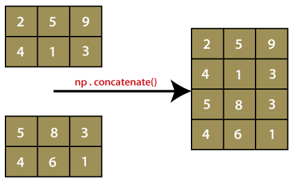

```python
x=np.array([[1,2],[3,4]])
y=np.array([[12,30]])
print(x)
print(y)
```

```
[[1 2]
 [3 4]]
[[12 30]]
```

```python
z=np.concatenate((x,y))
z
```

```
array([[ 1,  2],
       [ 3,  4],
       [12, 30]])
```

```python
x=np.array([[1,2],[3,4]])
y=np.array([[12,30]])
z=np.concatenate((x,y), axis=0)
z
```

```
array([[ 1,  2],
       [ 3,  4],
       [12, 30]])
```

```python
x=np.array([[1,2],[3,4]])
y=np.array([[12],[30]])
x
y
```

```
array([[12],
       [30]])
```

```python
z=np.concatenate((x,y), axis=1)
z
```

```
array([[ 1,  2, 12],
       [ 3,  4, 30]])
```

```python
x=np.array([[1,2],[3,4]])
y=np.array([[12,30]])
z=np.concatenate((x,y.T), axis=1)  #take the transpose to create a column array
z
```

```
array([[ 1,  2, 12],
       [ 3,  4, 30]])
```

#### **Exercise 6**

Write a NumPy program to create to concatenate two given arrays of shape (2, 2) and (2,1).

You are free to select the elements.

**Extra**

You can generate integers randomly.

```python
np.random.randint(1,5,2) #(min,max,size)
```

```
array([3, 1])
```

```python
np.random.randint(3,15,4) #(min,max,size)
```

```
array([13, 14, 13, 14])
```

You can generate same random numbers by using seed. You can write any number in the seed.

```python
np.random.seed(456)
np.random.random(5)
```

```
array([0.24875591, 0.16306678, 0.78364326, 0.80852339, 0.62562843])
```

```python
np.random.random(5)
```

```
array([0.60411363, 0.8857019 , 0.75911747, 0.18110506, 0.15016932])
```

```python
np.random.seed(456)
np.random.random(5)
```

```
array([0.24875591, 0.16306678, 0.78364326, 0.80852339, 0.62562843])
```

# Quiz 4

Please open a new notebook.

Create the following arrays.

x = [3 , 4.4, 5.8, 7.2, 8.6, 10]

y = [14.39, 20.14, 25.46, 31.53, 36.67,42.55]

**a) Calculate the mean of x**

**b) Calculate the median of y**

**c) Calculate the correlation between x and y**

**d) Concatenate the x and y as a array with shape (2,6)**

Download your notebook as .ipnyb file, and send it to metustat112@gmail.com